# R Problem of the Month

March 27, 2015

# Introduction

To introduce random variables to his elementary statistics students, Mr. Garza gives the following problem:

> Suppose a person throws a dart and hits a circular board of radius 9 inches. Let $Y$ denote the distance in inches from the point of impact to the top center of the board. Is $Y$ a discrete or a continuous random variable? What values does the continuous random variable $Y$ take on?

The answers are that $Y$ is a continous random variable and that it can take on any value between 0 and 18 inclusive.

The problem does not ask students to find probabilities involving $Y$. To do so would require calculating integrals or otherwise be very clever. But if he teaches his students R he may be able to ask them to approximate probabilites involving $Y$ by using [Monte Carlo methods](http://www.countbayesie.com/blog/2015/3/3/6-amazing-trick-with-monte-carlo-simulations).

Thus, the problem posed is this: assuming that all points on the dartboard are equally likely to be hit with the dart, find $P(0< Y<9)$ using R or other software.

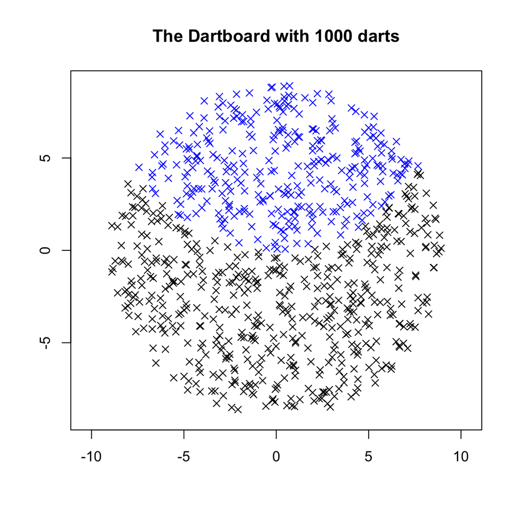